# Pós-graduação em Ciências Veterinárias (IV/UFRRJ)

Análise Exploratória de Dados (AED) - Uma Revisão

Profa. Adriana Andrade (DEMAT/ICE/UFRRJ) Prof. Wagner Tassinari (DEMAT/ICE/UFRRJ)

2021

[figure not shown]

# Para que serve a AED ?

- Em estatística, a análise exploratória de dados (AED) é uma abordagem à análise de conjuntos de dados de modo a resumir suas características principais, frequentemente com métodos visuais.
- Um modelo estatístico pode ou não ser usado, mas inicialmente a AED tem como objetivo observar o que os dados podem nos dizer além da modelagem formal ou do processo de testes de hipóteses.
- As técnicas da AED nos ajudam a extrair informações relevantes de um conjunto de dados.

[Fonte: Wikipédia](https://pt.wikipedia.org/wiki/An%C3%A1lise_explorat%C3%B3ria_de_dados)

# Etapas do AED

### 1. Conhecer a base de dados

- Tipos de variáveis
- Completude dos dados (preenchimento das variáveis - *missings data*)*
- Outliers

### 2. Utilização de medidas de estatística descritiva

- Contagens ou Distribuição de Frequências (Variáveis Qualitativas ou Categóricas)
- Medidas de tendência central e dispersão (Variáveis Quantitativas)
- Medidas de associação (Análises Bivariadas)
- Utilização de métodos visuais (gráficos)

# Prática

- Base de dados: daisy2.xlsx ([link](https://docs.google.com/spreadsheets/d/1wOVCA2Jk6bKMyvi84H602ftKRqdFq5Gw238_7dTMvJE/edit?usp=sharing))
- Conjunto de dados proveniente de um estudo tipo coorte a respeito das condições do manejo reprodutivo em rebanhos de bovinos leiteiros. O objetivo é avaliar o desempenho reprodutivo e a produção de leite desses animais.
- Dicionário de variáveis:

| Variáveis | Descrição | Tipo de Variáveis |
| --- | --- | --- |
| region | Regiões de estudo (1 a 4 regiões estudadas) | Categórica |
| herd | Identificador do rebanho | Contagem |
| cow | Identificador do animal | Contagem |
| study_lact | Lactação (Primeira ou segunda lactação no estudo) | Dicotômica |
| herd_size | Tamanho do rebanho | Contínua |
| mwp | Período de espera até a concepção | Contínua |
| parity | Número de lactações | Contagem |
| milk120 | Litros de leite nos primeiros 120 dias de lactação | Contínua |
| calv_dt | Data do parto | Data |
| cf | Intervalo parto/concepção ou *dias em aberto* | Contínua |
| fs | Concepção de primeira (1/0) | Dicotômica |
| cc | Intervalo do parto até a concepção | Contínua |
| wpc | Intervalo do período de espera atá a concepção | Contínua |
| spc | Serviços de concepção | Categórica |
| twin | Nascimento duplo (1/0) | Dicotômica |
| dyst | Complicações no parto (*Distocia fetal*) (1/0) | Dicotômica |
| rp | Retenção da placenta no parto (1/0) | Dicotômica |
| vag_disch | Corrimento vaginal observado (1/0) | Dicotômica |
| h7 | Indicador do subset do rebanho (1/0) | Dicotômica |

- Vamos supor que estamos interessados em estudar a relação entre **complicações no parto** em relação a algumas variáveis explicativas.
- Neste exemplo prático, vamos mostrar algumas técnicas de EAD para dados quantitativos e categóricos usando apenas algumas variáveis da base de dados daisy2.
- Serão escolhidas as variáveis:
  - **Variável de desfecho:** dyst
  - **Variáveis de explicativas:** mwp, parity, milk120, twin, rp, vag_disch

# Preparando o banco de dados

- Abra o banco de dados:

```r
library(readxl)
daisy2 <- read_excel("~/Google Drive/UFRRJ/Modelos Regressão 2021/Bancos/daisy2.xlsx")

daisy2 <- daisy2[daisy2$h7 == 1, ] # vamos apenas usar um subconjunto dos dados

head(daisy2)
```

```
# A tibble: 6 × 19
  region  herd   cow study_lact herd_size   mwp parity milk120 calv_dt    cf
   <dbl> <dbl> <dbl>      <dbl>     <dbl> <dbl>  <dbl>   <dbl>   <dbl> <dbl>
1      1     1     1          1       294    26      5   3506.   13464    80
2      1     1     2          1       294    26      5   3691.   13526    64
3      1     1     3          1       294    26      5   4173    13531    71
4      1     1     4          1       294    26      5   3727.   13556    35
5      1     1     5          1       294    26      5   3091.   13691    47
6      1     1     6          1       294    26      4   5041.   13438    NA
# … with 9 more variables: fs <dbl>, cc <dbl>, wpc <dbl>, spc <dbl>,
#   twin <dbl>, dyst <dbl>, rp <dbl>, vag_disch <dbl>, h7 <dbl>
```

Ou siga as seguintes etapas no RStudio: *Environment –> Import Dataset –> From Excel…*

- Selecione as variáveis para compor o banco que será trabalhado
  - *cow* - Identificador do animal
  - *dyst* - Complicações no parto (Distocia fetal)
  - *milk120* - Litros de leite nos primeiros 120 dias de lactação
  - *mwp* - Período de espera até a concepção
  - *parity* - Número de lactação
  - *twin* - Nascimento duplo
  - *rp* - Retenção da placenta no parto
  - *vag_disch* - Corrimento vaginal observado

```r
myvars <- c("cow", "dyst", "milk120", "mwp", "parity", "twin", "rp", "vag_disch")
banco <- daisy2[myvars]

head(banco)
```

```
# A tibble: 6 × 8
    cow  dyst milk120   mwp parity  twin    rp vag_disch
  <dbl> <dbl>   <dbl> <dbl>  <dbl> <dbl> <dbl>     <dbl>
1     1     0   3506.    26      5     0     0         0
2     2     0   3691.    26      5     0     0         0
3     3     0   4173     26      5     0     0         0
4     4     0   3727.    26      5     0     0         0
5     5     0   3091.    26      5     0     0         0
6     6     0   5041.    26      4     0     1         0
```

# Estruturando o banco de dados

```r
# Colocando os labels nas variáveis categóricas

# Complicações no parto
banco$dyst <- factor(banco$dyst, labels = c("Nao", "Sim"))
banco$dyst <- relevel(banco$dyst, "Sim")

# Nascimento duplo
banco$twin <- factor(banco$twin, labels = c("Nao", "Sim"))
banco$twin <- relevel(banco$twin, "Sim")

# Retenção da placenta no parto
banco$rp <- factor(banco$rp, labels = c("Nao", "Sim"))
banco$rp <- relevel(banco$rp, "Sim")

# Corrimento vaginal observado
banco$vag_disch <- factor(banco$vag_disch, labels = c("Nao", "Sim"))
banco$vag_disch <- relevel(banco$vag_disch, "Sim")
```

# Pacote *DataExplorer*

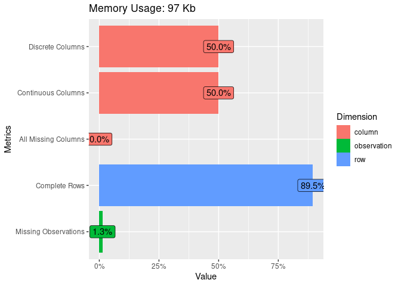

```r
library(DataExplorer)
plot_intro(banco)
```

[* Introduction to DataExplorer](https://cran.r-project.org/web/packages/DataExplorer/vignettes/dataexplorer-intro.html#replace-missing-values)

# Verificando a distribuição das variáveis categóricas

```r
# Complicações no parto
table(banco$dyst) # Freq simples
```

```
 Sim  Nao
 118 1858
```

```r
prop.table(table(banco$dyst)) # Freq relativa
```

```
      Sim       Nao
0.0597166 0.9402834
```

```r
# Nascimento duplo
table(banco$twin) # Freq simples
```

```
 Sim  Nao
  50 1926
```

```r
prop.table(table(banco$twin)) # Freq relativa
```

```
       Sim        Nao
0.02530364 0.97469636
```

```r
# Retenção da placenta no parto
table(banco$rp) # Freq simples
```

```
 Sim  Nao
 199 1777
```

```r
prop.table(table(banco$rp)) # Freq relativa
```

```
      Sim       Nao
0.1007085 0.8992915
```

```r
# Corrimento vaginal observado
table(banco$vag_disch) # Freq simples
```

```
 Sim  Nao
 109 1867
```

```r
prop.table(table(banco$vag_disch)) # Freq relativa
```

```
       Sim        Nao
0.05516194 0.94483806
```

# Verificando a distribuição das variáveis categóricas graficamente

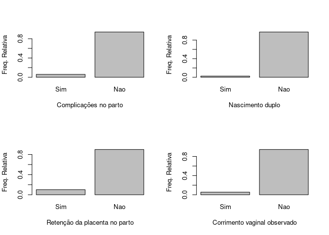

```r
par(mfrow=c(2,2))
barplot(prop.table(table(banco$dyst)), ylab = "Freq. Relativa", xlab = "Complicações no parto")
barplot(prop.table(table(banco$twin)), ylab = "Freq. Relativa", xlab = "Nascimento duplo")
barplot(prop.table(table(banco$rp)), ylab = "Freq. Relativa", xlab = "Retenção da placenta no parto")
barplot(prop.table(table(banco$vag_disch)), ylab = "Freq. Relativa", xlab = "Corrimento vaginal observado")
```

# Verificando a distribuição das variáveis quantitativas

```r
# Produção de leite nos primeiros 120 dias de lactação
summary(banco$milk120)
```

```
   Min. 1st Qu.  Median    Mean 3rd Qu.    Max.    NA's
   1110    2742    3226    3225    3693    5630     208
```

```r
# Período de espera até a concepção
summary(banco$mwp)
```

```
   Min. 1st Qu.  Median    Mean 3rd Qu.    Max.
  21.00   26.00   40.00   35.84   44.00   50.00
```

```r
# Números de lactações
summary(banco$parity)
```

```
   Min. 1st Qu.  Median    Mean 3rd Qu.    Max.
  1.000   2.000   3.000   2.911   4.000   7.000
```

# Verificando a distribuição das variáveis quantitativas graficamente

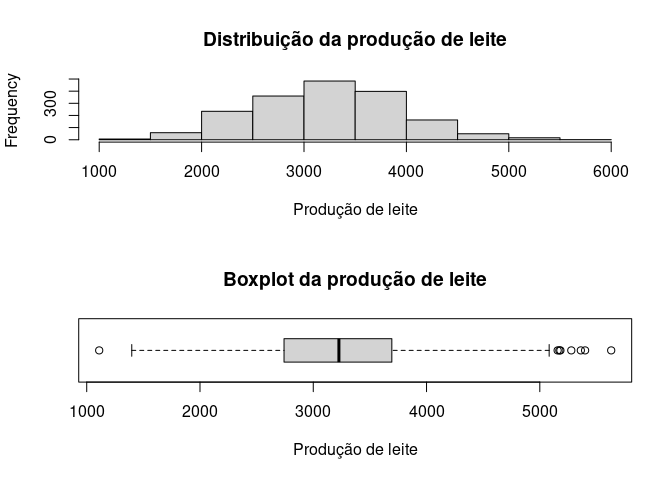

```r
par(mfrow=c(2,1))
hist(banco$milk120, xlab = "Produção de leite",
                  main="Distribuição da produção de leite")
boxplot(banco$milk120, xlab = "Produção de leite",
                main="Boxplot da produção de leite", horizontal=TRUE)
```

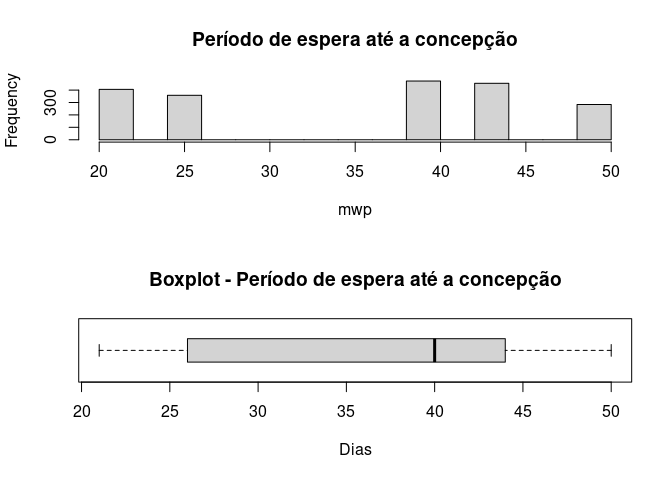

```r
par(mfrow=c(2,1))
hist(banco$mwp, xlab = "mwp",
                  main="Período de espera até a concepção")
boxplot(banco$mwp, xlab = "Dias",
                main="Boxplot - Período de espera até a concepção", horizontal=TRUE)
```

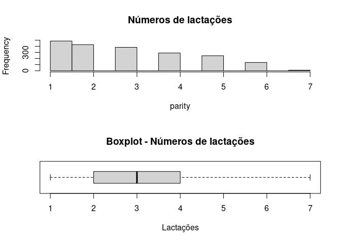

```r
par(mfrow=c(2,1))
hist(banco$parity, xlab = "parity",
                  main="Números de lactações")
boxplot(banco$parity, xlab = "Lactações",
                main="Boxplot - Números de lactações", horizontal=TRUE)
```

# Categorizando a variável parity

```r
banco$parity_cat <- cut((banco$parity), breaks = c(0, 1, 2, 4, Inf), labels = c("Até 1",
    "1 a 2", "2 a 4", "Mais de 4"))
table(banco$parity_cat)
```

```
    Até 1     1 a 2     2 a 4 Mais de 4
      486       427       673       390
```

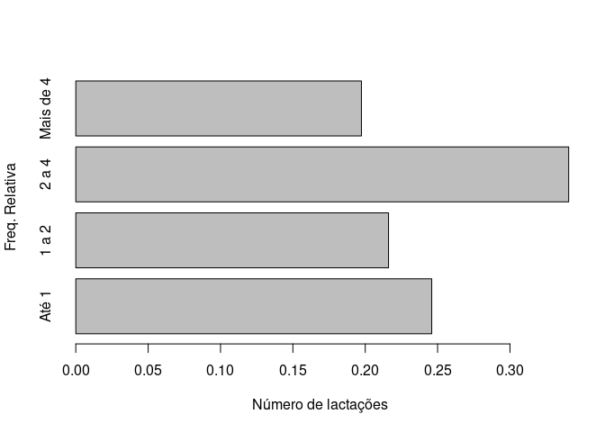

```r
barplot(prop.table(table(banco$parity_cat)), ylab = "Freq. Relativa", xlab = "Número de lactações", horiz=TRUE)
```

# Distribuição das complicações no parto segundo o número de lactações

- Utilizando o pacote *gmodels* [link](https://www.rdocumentation.org/packages/gmodels)

```r
library(gmodels)

CrossTable(banco$parity_cat, banco$dyst, digits=2, prop.r=FALSE,
           prop.c=TRUE, prop.t=FALSE, prop.chisq=FALSE,
           chisq = FALSE, fisher=FALSE, mcnemar=FALSE)
```

```
   Cell Contents
|-------------------------|
|                       N |
|           N / Col Total |
|-------------------------|


Total Observations in Table:  1976


                 | banco$dyst
banco$parity_cat |       Sim |       Nao | Row Total |
-----------------|-----------|-----------|-----------|
           Até 1 |        67 |       419 |       486 |
                 |      0.57 |      0.23 |           |
-----------------|-----------|-----------|-----------|
           1 a 2 |        21 |       406 |       427 |
                 |      0.18 |      0.22 |           |
-----------------|-----------|-----------|-----------|
           2 a 4 |        18 |       655 |       673 |
                 |      0.15 |      0.35 |           |
-----------------|-----------|-----------|-----------|
       Mais de 4 |        12 |       378 |       390 |
                 |      0.10 |      0.20 |           |
-----------------|-----------|-----------|-----------|
    Column Total |       118 |      1858 |      1976 |
                 |      0.06 |      0.94 |           |
-----------------|-----------|-----------|-----------|
```

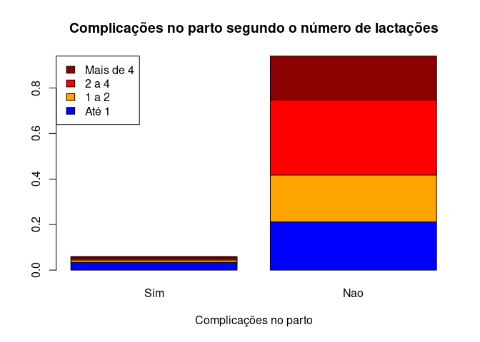

```r
# Stacked Bar Plot

tabela <- table(banco$parity_cat, banco$dyst)

barplot(prop.table(tabela), main="Complicações no parto segundo o número de lactações",
        xlab="Complicações no parto", col=c("blue", "orange", "red", "darkred"),
        legend = rownames(tabela), args.legend = list(x = 'topleft'))
```

# Distribuição das complicações no parto segundo o nascimento duplo

```r
gmodels::CrossTable(banco$twin, banco$dyst, digits=2, prop.r=FALSE,
           prop.c=TRUE, prop.t=FALSE, prop.chisq=FALSE,
           chisq = FALSE, fisher=FALSE, mcnemar=FALSE)
```

```
   Cell Contents
|-------------------------|
|                       N |
|           N / Col Total |
|-------------------------|


Total Observations in Table:  1976


             | banco$dyst
  banco$twin |       Sim |       Nao | Row Total |
-------------|-----------|-----------|-----------|
         Sim |         5 |        45 |        50 |
             |      0.04 |      0.02 |           |
-------------|-----------|-----------|-----------|
         Nao |       113 |      1813 |      1926 |
             |      0.96 |      0.98 |           |
-------------|-----------|-----------|-----------|
Column Total |       118 |      1858 |      1976 |
             |      0.06 |      0.94 |           |
-------------|-----------|-----------|-----------|
```

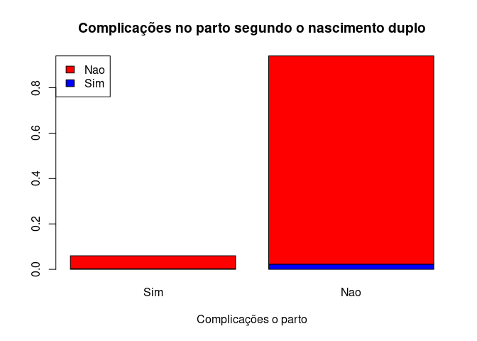

```r
# Stacked Bar Plot

tabela <- table(banco$twin, banco$dyst)

barplot(prop.table(tabela), main="Complicações no parto segundo o nascimento duplo",
        xlab="Complicações o parto", col=c("blue", "red"),
        legend = rownames(tabela), args.legend = list(x = 'topleft'))
```

# Distribuição das complicações no parto segundo a retenção da placenta no parto

```r
gmodels::CrossTable(banco$rp, banco$dyst, digits=2, prop.r=FALSE,
                    prop.c=TRUE, prop.t=FALSE, prop.chisq=FALSE,
                    chisq = FALSE, fisher=FALSE, mcnemar=FALSE)
```

```
   Cell Contents
|-------------------------|
|                       N |
|           N / Col Total |
|-------------------------|


Total Observations in Table:  1976


             | banco$dyst
    banco$rp |       Sim |       Nao | Row Total |
-------------|-----------|-----------|-----------|
         Sim |        19 |       180 |       199 |
             |      0.16 |      0.10 |           |
-------------|-----------|-----------|-----------|
         Nao |        99 |      1678 |      1777 |
             |      0.84 |      0.90 |           |
-------------|-----------|-----------|-----------|
Column Total |       118 |      1858 |      1976 |
             |      0.06 |      0.94 |           |
-------------|-----------|-----------|-----------|
```

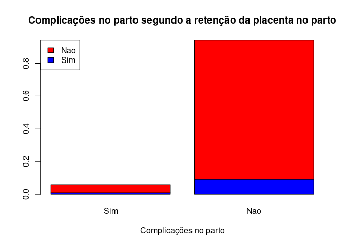

```r
# Stacked Bar Plot

tabela <- table(banco$rp, banco$dyst)

barplot(prop.table(tabela), main="Complicações no parto segundo a retenção da placenta no parto",
        xlab="Complicações no parto", col=c("blue", "red"),
        legend = rownames(tabela), args.legend = list(x = 'topleft'))
```

# Distribuição da produção do leite segundo complicações no parto

```r
by(banco$milk120, banco$dyst, summary)
```

```
banco$dyst: Sim
   Min. 1st Qu.  Median    Mean 3rd Qu.    Max.    NA's
   1398    2675    3060    3063    3437    4619      12
------------------------------------------------------------
banco$dyst: Nao
   Min. 1st Qu.  Median    Mean 3rd Qu.    Max.    NA's
   1110    2750    3245    3236    3704    5630     196
```

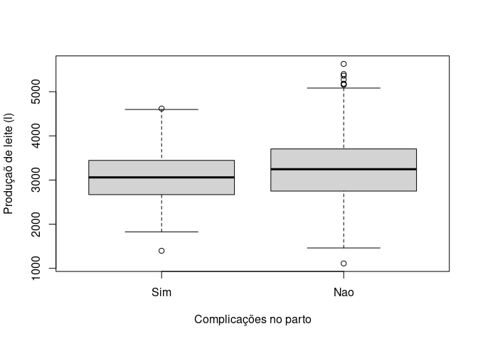

```r
boxplot(milk120 ~ dyst, banco, ylab="Produçaõ de leite (l)", xlab = "Complicações no parto")
```

# Distribuição do número de lactações segundo complicações no parto

```r
by(banco$parity, banco$dyst,summary)
```

```
banco$dyst: Sim
   Min. 1st Qu.  Median    Mean 3rd Qu.    Max.
  1.000   1.000   1.000   2.008   2.750   6.000
------------------------------------------------------------
banco$dyst: Nao
   Min. 1st Qu.  Median    Mean 3rd Qu.    Max.
  1.000   2.000   3.000   2.968   4.000   7.000
```

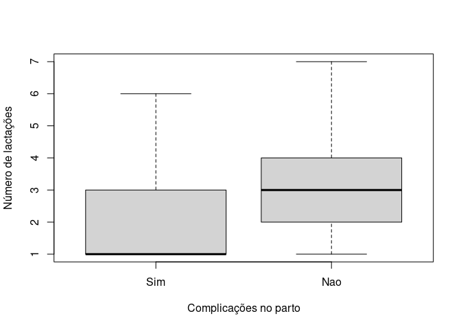

```r
boxplot(parity ~ dyst, banco, ylab="Número de lactações", xlab = "Complicações no parto")
```

# Análise univariada e bivariada utilizando o pacote *tableone*

## Análise univariada

```r
library(tableone)

# Selecionando as variaveis que irao compor a tabela

myVars <- c("dyst", "milk120", "mwp", "parity", "parity_cat", "twin", "rp", "vag_disch")

## criando o objeto da TableOne

tabela1 <- CreateTableOne(vars = myVars, data = banco)

print(tabela1, showAllLevels = TRUE)
```

```
                      level     Overall
  n                                1976
  dyst (%)            Sim           118 ( 6.0)
                      Nao          1858 (94.0)
  milk120 (mean (SD))           3225.31 (703.36)
  mwp (mean (SD))                 35.84 (10.52)
  parity (mean (SD))               2.91 (1.59)
  parity_cat (%)      Até 1         486 (24.6)
                      1 a 2         427 (21.6)
                      2 a 4         673 (34.1)
                      Mais de 4     390 (19.7)
  twin (%)            Sim            50 ( 2.5)
                      Nao          1926 (97.5)
  rp (%)              Sim           199 (10.1)
                      Nao          1777 (89.9)
  vag_disch (%)       Sim           109 ( 5.5)
                      Nao          1867 (94.5)
```

[*Introduction to tableone*](https://cran.r-project.org/web/packages/tableone/vignettes/introduction.html)

## Análise bivariada, utilizando a variável complicações no parto como desfecho

```r
myVars2 <- c("milk120", "mwp", "parity", "parity_cat", "twin", "rp", "vag_disch")

tabela2 <- CreateTableOne(vars = myVars2, strata = "dyst",                                             data = banco)
print(tabela2, showAllLevels = TRUE)
```

```
                     Stratified by dyst
                      level     Sim              Nao              p      test
  n                                 118             1858
  milk120 (mean (SD))           3063.10 (601.85) 3235.66 (708.24)  0.014
  mwp (mean (SD))                 40.54 (7.67)     35.54 (10.60)  <0.001
  parity (mean (SD))               2.01 (1.45)      2.97 (1.58)   <0.001
  parity_cat (%)      Até 1          67 (56.8)       419 (22.6)   <0.001
                      1 a 2          21 (17.8)       406 (21.9)
                      2 a 4          18 (15.3)       655 (35.3)
                      Mais de 4      12 (10.2)       378 (20.3)
  twin (%)            Sim             5 ( 4.2)        45 ( 2.4)    0.360
                      Nao           113 (95.8)      1813 (97.6)
  rp (%)              Sim            19 (16.1)       180 ( 9.7)    0.037
                      Nao            99 (83.9)      1678 (90.3)
  vag_disch (%)       Sim            19 (16.1)        90 ( 4.8)   <0.001
                      Nao            99 (83.9)      1768 (95.2)
```